```python
!pip install tmdbsimple
!pip install python-dateutil
!pip install ggplot
import numpy as np
from ggplot import *
import pandas as pd
import tmdbsimple as tmdb
import time
import datetime
from dateutil import parser
import matplotlib.pyplot as plt
from sklearn import linear_model
import sklearn.datasets as ds
import statsmodels.api as sm
from sklearn.feature_selection import f_regression
```

```
    100% |████████████████████████████████| 2.2MB 369kB/s ta 0:00:011    91% |█████████████████████████████▏  | 2.0MB 2.2MB/s eta 0:00:01
```

# TMDb Data Analysis

## Ian Hammer, Ryan Kiernan

This project is a case study in data gathered from "The Movie Database." Using data for both movies and TV shows, we test the following hypotheses:

Part 1:

1. There is a relationship between a TV show's genre and its ratings + number of seasons

Part 2:

1. There is a positive relationship between age and movie reviews
2. Summer movies are worse than other movies

## Part I: How closely related are a TV show's user rating, genre, and number of seasons?

### Introduction & Hypothesis:

From The Honeymooners to Game of Thrones, television series have been a staple of American culture for nearly seven decades. Some don't last long before falling to the proverbial network axe (Freaks & Geeks, Twin Peaks) and subsequently gain cult followings, while others become major successes for their networks and either shape the genre for years to follow (Seinfeld, Breaking Bad) or become stale after running for a certain number of seasons (Arrow). We'd like to learn more about the latter category of shows, more specifically what separates the shows that sustain greatness from those that lose their touch. Do shows of a certain genre [jump the shark](http://tvtropes.org/pmwiki/pmwiki.php/Main/JumpingTheShark) after being on air for so long?

We hypothesize that we can relate a show's rating, genre, and number of seasons together. We believe that "thinker" genres, like Drama, Crime, and Sci-Fi/Fantasy will tend to have shows that have higher user ratings but lower seasons compared to genres like Comedy and Action, which will have lower user ratings but more seasons.

We will test our hypothesis using data from an open source movie database, [TMDb](https://www.themoviedb.org), and a python wrapper for it called tmdbsimple, of which a quick demo is shown below. More documentation of this wrapper can be found [here](https://github.com/celiao/tmdbsimple).

Steps to test are as follows:

1. Gathering data on shows with more than 200 votes and 4 or more seasons
2. Cleaning and organizing the data in a pandas table
3. Visualizing this data graphically
4. Getting models to predict a show's rating and expected number of seasons

```python
tmdb.API_KEY = '0b6ab414e6fd79648a868782b0750b09'
```

```python
tv = tmdb.TV(456) #Keep these cells as demo for tmdb api?
info = tv.info() #JSON rep of show info
info['overview']
```

```
'Set in Springfield, the average American town, the show focuses on the antics and everyday adventures of the Simpson family; Homer, Marge, Bart, Lisa and Maggie, as well as a virtual cast of thousands. Since the beginning, the series has been a pop culture icon, attracting hundreds of celebrities t…
```

```python
genres = info.get('genres')
```

```python
for x in genres:
    print(x['name'])
```

```
Animation
Comedy
```

### Data Collection

Here we scrape data from shows which are 4+ seasons long and 200+ user votes. Collection of data took a while both because the TMDb API only allows 240 requests/min - which was accounted for by "sleeping" our process after each API call - and because we didn't have any way to get a good range of TV ids that TMDb uses to index TV shows, so we didn't come across many shows in the first 30000 possible ids that matched our criteria. We ended up collecting rating, genre, episode and popularity data on 75 TV shows.

```python
tv_id = 1
shows = []
ratings = []
genres = []
seasons = []
pops = []
episodes = []
ids = []

while (tv_id < 30000):
    tv = tmdb.TV(tv_id)
    time.sleep(.251)

    try:
        #get info from JSON object returned from request
        info = tv.info()
        name = info.get('name')
        season_no = info.get('number_of_seasons')
        episode = info.get('number_of_episodes')
        rating = info.get('vote_average')
        genre_s = info.get('genres')
        genre = ""
        pop = info.get('popularity')
        votes = info.get('vote_count')
        for x in genre_s: #just get name of
            genre += x['name'] + "/"


        if votes >= 200 and season_no >= 4:
            shows.append(name)
            ids.append(tv_id)
            ratings.append(rating)
            genres.append(genre)
            episodes.append(episode)
            seasons.append(season_no)
            pops.append(pop)

    except:
        pass

    if tv_id == 5920: #account for some gaps in data
        tv_id = 8592
    elif tv_id == 8592:
        tv_id = 10283
    elif tv_id == 10545:
        tv_id = 17962
    else:
        tv_id += 1
```

### Dataframe

Once we collected all of our data into lists, we wrote and saved this data to a tabbed separated value file (tsv) so that we could jump back into our analysis at any time without having to wait hours to collect again using the API.

```python
with open("TVout.tsv", "a") as f: #title the respective columns
        print ("%s\t%s\t%s\t%s\t%s\t%s\t%s" % ("show", "tv_id", "rating", "seasons", "episodes", "popularity", "genres"), file=f)
```

```python
with open("TVout.tsv", "a") as f: #write all of our values in the lists
    for x in range(len(shows)):
        print ("%s\t%d\t%f\t%d\t%d\t%f\t%s" % (shows[x], ids[x], ratings[x], seasons[x], episodes[x], pops[x], genres[x]), file=f)
```

Now we can access this data anytime by putting it into a pandas DataFrame object.

```python
df1 = pd.DataFrame.from_csv("TVout.tsv", sep='\t')
```

```python
df1.head()
```

| show | tv_id | rating | seasons | episodes | popularity | genres |
| --- | --- | --- | --- | --- | --- | --- |
| Top Gear | 45 | 7.5 | 24 | 176 | 33.498923 | Documentary/Comedy/ |
| That '70s Show | 52 | 7.3 | 8 | 200 | 27.289507 | Comedy/ |
| Buffy the Vampire Slayer | 95 | 8.0 | 7 | 144 | 20.664035 | Comedy/Drama/Sci-Fi & Fantasy/ |
| Weeds | 186 | 7.1 | 8 | 102 | 18.432312 | Drama/Comedy/ |
| Star Trek: Enterprise | 314 | 7.4 | 4 | 98 | 18.592752 | Action & Adventure/Drama/Sci-Fi & Fantasy/ |

We can use this dataframe and separate how we see fit. Like getting only shows with 5 seasons

```python
five = df1[df1["seasons"] == 5]
```

```python
five
```

| show | tv_id | rating | seasons | episodes | popularity | genres |
| --- | --- | --- | --- | --- | --- | --- |
| Six Feet Under | 1274 | 8.2 | 5 | 63 | 15.665654 | Drama/ |
| Breaking Bad | 1396 | 8.2 | 5 | 62 | 45.275608 | Drama/ |
| Marvel's Agents of S.H.I.E.L.D. | 1403 | 6.7 | 5 | 106 | 64.841267 | Fantasy/Drama/Action/Adventure/Science Fiction/ |
| Chuck | 1404 | 7.5 | 5 | 91 | 15.665384 | Action & Adventure/Comedy/Drama/ |
| Person of Interest | 1411 | 7.6 | 5 | 103 | 26.970550 | Action/Adventure/Drama/Mystery/Thriller/ |
| Elementary | 1415 | 6.9 | 5 | 120 | 27.396723 | Drama/Mystery/Crime/ |
| Ray Donovan | 1423 | 7.3 | 5 | 60 | 18.806580 | Drama/ |
| Orange Is the New Black | 1424 | 7.4 | 5 | 65 | 21.535003 | Comedy/Drama/ |
| House of Cards | 1425 | 8.1 | 5 | 65 | 32.350274 | Drama/ |
| The Wire | 1438 | 8.2 | 5 | 60 | 20.021124 | Drama/Crime/ |
| Boardwalk Empire | 1621 | 7.7 | 5 | 56 | 12.469265 | Drama/Crime/ |
| Fringe | 1705 | 8.0 | 5 | 100 | 21.509805 | Sci-Fi & Fantasy/Drama/Mystery/ |
| Prison Break | 2288 | 7.5 | 5 | 88 | 38.702506 | Action & Adventure/Crime/Drama/ |
| Stargate Atlantis | 2290 | 7.8 | 5 | 100 | 14.303615 | Action & Adventure/Drama/Sci-Fi & Fantasy/ |
| Arrested Development | 4589 | 8.1 | 5 | 68 | 25.168055 | Comedy/ |

Or shows that are strictly classified as comedy

```python
comedy = df1[df1["genres"] == "Comedy/"]
```

```python
comedy
```

| show | tv_id | rating | seasons | episodes | popularity | genres |
| --- | --- | --- | --- | --- | --- | --- |
| That '70s Show | 52 | 7.3 | 8 | 200 | 27.289507 | Comedy/ |
| How I Met Your Mother | 1100 | 7.4 | 9 | 208 | 32.145424 | Comedy/ |
| Seinfeld | 1400 | 8.2 | 9 | 193 | 27.224453 | Comedy/ |
| The Big Bang Theory | 1418 | 6.9 | 11 | 254 | 220.309448 | Comedy/ |
| New Girl | 1420 | 6.4 | 7 | 139 | 24.215878 | Comedy/ |
| Modern Family | 1421 | 7.2 | 9 | 198 | 48.947379 | Comedy/ |
| Friends | 1668 | 7.8 | 10 | 236 | 51.479031 | Comedy/ |
| The Fresh Prince of Bel-Air | 1892 | 7.3 | 6 | 148 | 8.855756 | Comedy/ |
| Malcolm in the Middle | 2004 | 7.4 | 7 | 151 | 15.092547 | Comedy/ |
| The Office | 2316 | 7.9 | 9 | 195 | 24.058980 | Comedy/ |
| The IT Crowd | 2490 | 8.1 | 4 | 24 | 16.562091 | Comedy/ |
| Two and a Half Men | 2691 | 6.1 | 12 | 262 | 40.757220 | Comedy/ |
| It's Always Sunny in Philadelphia | 2710 | 8.0 | 12 | 133 | 25.600534 | Comedy/ |
| Married... with Children | 4239 | 7.4 | 11 | 259 | 21.805467 | Comedy/ |
| Arrested Development | 4589 | 8.1 | 5 | 68 | 25.168055 | Comedy/ |
| Parks and Recreation | 8592 | 7.6 | 7 | 125 | 26.267542 | Comedy/ |
| Community | 18347 | 7.8 | 6 | 110 | 30.278715 | Comedy/ |

### Some early basic visualization

How does the data look just by taking into account the rating as dependent on the number of seasons a show has?

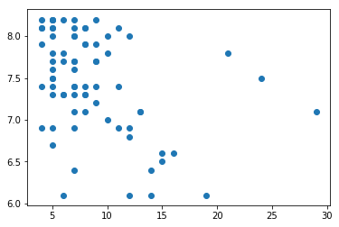

```python
plt.scatter(df1.seasons, df1.rating)
plt.show()
```

The peak ratings seem to be at around the 5-7 seasons mark, but they also have some low ratings in that range as well.

What about comedy?

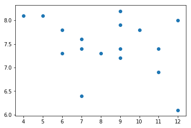

```python
plt.scatter(comedy.seasons, comedy.rating)
plt.show()
```

### Some more in-depth analysis

Our dataframe is somewhat messy, especially with the "genre" column. The data doesn't distinguish Action & Adventure/Comedy from Comedy/Action & Adventure and there are too many variations of similar genres which would make analysis on genres too difficult. Let's fix that by assigning genre ids based on the "strongest" genre in a show's "genre" column.

```python
def genre_id(genre):
    if "Animation" in genre:
        return 2
    if "Action" in genre and "Adventure" in genre:
        return 0
    if "Comedy" in genre and "Drama" in genre:
        return 1
    if "Comedy" in genre:
        return 3
    if "Crime" in genre and "Drama" in genre:
        return 4
    if "Fantasy" in genre or "Sci" in genre:
        return 5
    if "Drama" in genre:
        return 6
    return -1
```

```python
genre_key = []
for x in df1.genres:
    genre_key.append(genre_id(x))

df1["genre_id"] = genre_key
df1.head()
```

| show | tv_id | rating | seasons | episodes | popularity | genres | genre_id |
| --- | --- | --- | --- | --- | --- | --- | --- |
| Top Gear | 45 | 7.5 | 24 | 176 | 33.498923 | Documentary/Comedy/ | 3 |
| That '70s Show | 52 | 7.3 | 8 | 200 | 27.289507 | Comedy/ | 3 |
| Buffy the Vampire Slayer | 95 | 8.0 | 7 | 144 | 20.664035 | Comedy/Drama/Sci-Fi & Fantasy/ | 1 |
| Weeds | 186 | 7.1 | 8 | 102 | 18.432312 | Drama/Comedy/ | 1 |
| Star Trek: Enterprise | 314 | 7.4 | 4 | 98 | 18.592752 | Action & Adventure/Drama/Sci-Fi & Fantasy/ | 0 |

Now we can use the genre_id field to better model a show's predicted rating as a function of the number of seasons it has, its genre association, and its popularity on TMDb. We use the statmodel library's Ordinary Least Squares tool to generate all linear models from this point on. A good [infographic](http://setosa.io/ev/ordinary-least-squares-regression/) on OLS can be used for those more interested in the topic.

```python
model = sm.OLS.from_formula('rating ~ seasons + genre_id + popularity + popularity * seasons * genre_id', data=df1)
results = model.fit()
results.summary()
```

OLS Regression Results

| Dep. Variable: | rating | R-squared: | 0.256 |
| --- | --- | --- | --- |
| Model: | OLS | Adj. R-squared: | 0.178 |
| Method: | Least Squares | F-statistic: | 3.287 |
| Date: | Sat, 16 Dec 2017 | Prob (F-statistic): | 0.00460 |
| Time: | 01:07:00 | Log-Likelihood: | -55.514 |
| No. Observations: | 75 | AIC: | 127.0 |
| Df Residuals: | 67 | BIC: | 145.6 |
| Df Model: | 7 |  |  |
| Covariance Type: | nonrobust |  |  |

|  | coef | std err | t | P>\|t\| | [0.025 | 0.975] |
| --- | --- | --- | --- | --- | --- | --- |
| Intercept | 7.8449 | 0.525 | 14.957 | 0.000 | 6.798 | 8.892 |
| seasons | -0.0280 | 0.072 | -0.390 | 0.698 | -0.172 | 0.115 |
| genre_id | 0.0531 | 0.200 | 0.266 | 0.791 | -0.346 | 0.452 |
| popularity | -0.0090 | 0.009 | -1.001 | 0.321 | -0.027 | 0.009 |
| popularity:seasons | 0.0008 | 0.001 | 0.705 | 0.483 | -0.001 | 0.003 |
| popularity:genre_id | 0.0017 | 0.005 | 0.374 | 0.710 | -0.007 | 0.011 |
| seasons:genre_id | -0.0059 | 0.027 | -0.220 | 0.827 | -0.059 | 0.048 |
| popularity:seasons:genre_id | -0.0003 | 0.001 | -0.529 | 0.598 | -0.001 | 0.001 |

| Omnibus: | 4.458 | Durbin-Watson: | 1.962 |
| --- | --- | --- | --- |
| Prob(Omnibus): | 0.108 | Jarque-Bera (JB): | 4.410 |
| Skew: | -0.557 | Prob(JB): | 0.110 |
| Kurtosis: | 2.587 | Cond. No. | 1.87e+04 |

Predict a tv shows rating as a function of the number of seasons, its genre, and popularity. Let's add the predicted rating field to our dataframe

```python
ols_predict = results.fittedvalues
df1["predicted_rating"] = ols_predict
df1.head()
```

| show | tv_id | rating | seasons | episodes | popularity | genres | genre_id | predicted_rating |
| --- | --- | --- | --- | --- | --- | --- | --- | --- |
| Top Gear | 45 | 7.5 | 24 | 176 | 33.498923 | Documentary/Comedy/ | 3 | 6.750459 |
| That '70s Show | 52 | 7.3 | 8 | 200 | 27.289507 | Comedy/ | 3 | 7.525510 |
| Buffy the Vampire Slayer | 95 | 8.0 | 7 | 144 | 20.664035 | Comedy/Drama/Sci-Fi & Fantasy/ | 1 | 7.583618 |
| Weeds | 186 | 7.1 | 8 | 102 | 18.432312 | Drama/Comedy/ | 1 | 7.567429 |
| Star Trek: Enterprise | 314 | 7.4 | 4 | 98 | 18.592752 | Action & Adventure/Drama/Sci-Fi & Fantasy/ | 0 | 7.623380 |

In linear regression, residuals are the difference between data's actual value and it's expected value. Let's calculate them and add them. Learn more about how residuals are used in linear regression [here](http://docs.statwing.com/interpreting-residual-plots-to-improve-your-regression/) .

```python
df1['rating_residuals'] = df1['rating'] - df1['predicted_rating']
df1.head()
```

| show | tv_id | rating | seasons | episodes | popularity | genres | genre_id | predicted_rating | rating_residuals |
| --- | --- | --- | --- | --- | --- | --- | --- | --- | --- |
| Top Gear | 45 | 7.5 | 24 | 176 | 33.498923 | Documentary/Comedy/ | 3 | 6.750459 | 0.749541 |
| That '70s Show | 52 | 7.3 | 8 | 200 | 27.289507 | Comedy/ | 3 | 7.525510 | -0.225510 |
| Buffy the Vampire Slayer | 95 | 8.0 | 7 | 144 | 20.664035 | Comedy/Drama/Sci-Fi & Fantasy/ | 1 | 7.583618 | 0.416382 |
| Weeds | 186 | 7.1 | 8 | 102 | 18.432312 | Drama/Comedy/ | 1 | 7.567429 | -0.467429 |
| Star Trek: Enterprise | 314 | 7.4 | 4 | 98 | 18.592752 | Action & Adventure/Drama/Sci-Fi & Fantasy/ | 0 | 7.623380 | -0.223380 |

Now we model a show's expected number of seasons as a function of user rating, it's genre, and popularity.

```python
model = sm.OLS.from_formula('seasons ~ rating + genre_id + popularity + popularity * rating * genre_id', data=df1)
results = model.fit()
results.summary()
```

OLS Regression Results

| Dep. Variable: | seasons | R-squared: | 0.283 |
| --- | --- | --- | --- |
| Model: | OLS | Adj. R-squared: | 0.209 |
| Method: | Least Squares | F-statistic: | 3.785 |
| Date: | Sat, 16 Dec 2017 | Prob (F-statistic): | 0.00162 |
| Time: | 01:07:19 | Log-Likelihood: | -209.09 |
| No. Observations: | 75 | AIC: | 434.2 |
| Df Residuals: | 67 | BIC: | 452.7 |
| Df Model: | 7 |  |  |
| Covariance Type: | nonrobust |  |  |

|  | coef | std err | t | P>\|t\| | [0.025 | 0.975] |
| --- | --- | --- | --- | --- | --- | --- |
| Intercept | 36.0550 | 32.413 | 1.112 | 0.270 | -28.641 | 100.751 |
| rating | -3.7913 | 4.285 | -0.885 | 0.379 | -12.344 | 4.761 |
| genre_id | -2.3662 | 9.139 | -0.259 | 0.796 | -20.607 | 15.875 |
| popularity | -0.3411 | 0.558 | -0.611 | 0.543 | -1.455 | 0.773 |
| popularity:rating | 0.0488 | 0.075 | 0.648 | 0.519 | -0.102 | 0.199 |
| popularity:genre_id | 0.0656 | 0.172 | 0.381 | 0.704 | -0.278 | 0.409 |
| rating:genre_id | 0.2466 | 1.204 | 0.205 | 0.838 | -2.157 | 2.651 |
| popularity:rating:genre_id | -0.0067 | 0.023 | -0.286 | 0.776 | -0.053 | 0.040 |

| Omnibus: | 40.833 | Durbin-Watson: | 1.663 |
| --- | --- | --- | --- |
| Prob(Omnibus): | 0.000 | Jarque-Bera (JB): | 118.317 |
| Skew: | 1.756 | Prob(JB): | 2.03e-26 |
| Kurtosis: | 8.053 | Cond. No. | 8.01e+04 |

```python
ols_predict = results.fittedvalues
df1["predicted_seasons"] = ols_predict
df1.head()
```

| show | tv_id | rating | seasons | episodes | popularity | genres | genre_id | predicted_rating | rating_residuals | predicted_seasons |
| --- | --- | --- | --- | --- | --- | --- | --- | --- | --- | --- |
| Top Gear | 45 | 7.5 | 24 | 176 | 33.498923 | Documentary/Comedy/ | 3 | 6.750459 | 0.749541 | 8.453809 |
| That '70s Show | 52 | 7.3 | 8 | 200 | 27.289507 | Comedy/ | 3 | 7.525510 | -0.225510 | 8.465755 |
| Buffy the Vampire Slayer | 95 | 8.0 | 7 | 144 | 20.664035 | Comedy/Drama/Sci-Fi & Fantasy/ | 1 | 7.583618 | 0.416382 | 6.595649 |
| Weeds | 186 | 7.1 | 8 | 102 | 18.432312 | Drama/Comedy/ | 1 | 7.567429 | -0.467429 | 8.951229 |
| Star Trek: Enterprise | 314 | 7.4 | 4 | 98 | 18.592752 | Action & Adventure/Drama/Sci-Fi & Fantasy/ | 0 | 7.623380 | -0.223380 | 8.366738 |

```python
df1["seasons_residuals"] = df1["seasons"] - df1["predicted_seasons"]
df1.head()
```

| show | tv_id | rating | seasons | episodes | popularity | genres | genre_id | predicted_rating | rating_residuals | predicted_seasons | seasons_residuals |
| --- | --- | --- | --- | --- | --- | --- | --- | --- | --- | --- | --- |
| Top Gear | 45 | 7.5 | 24 | 176 | 33.498923 | Documentary/Comedy/ | 3 | 6.750459 | 0.749541 | 8.453809 | 15.546191 |
| That '70s Show | 52 | 7.3 | 8 | 200 | 27.289507 | Comedy/ | 3 | 7.525510 | -0.225510 | 8.465755 | -0.465755 |
| Buffy the Vampire Slayer | 95 | 8.0 | 7 | 144 | 20.664035 | Comedy/Drama/Sci-Fi & Fantasy/ | 1 | 7.583618 | 0.416382 | 6.595649 | 0.404351 |
| Weeds | 186 | 7.1 | 8 | 102 | 18.432312 | Drama/Comedy/ | 1 | 7.567429 | -0.467429 | 8.951229 | -0.951229 |
| Star Trek: Enterprise | 314 | 7.4 | 4 | 98 | 18.592752 | Action & Adventure/Drama/Sci-Fi & Fantasy/ | 0 | 7.623380 | -0.223380 | 8.366738 | -4.366738 |

### Some better visualization

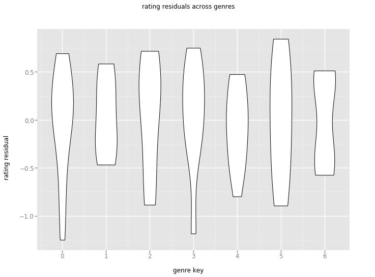

```python
ggplot(aes(x='genre_id', y='rating_residuals'), data=df1) +\
    geom_violin() +\
    labs(title="rating residuals across genres",
         x = "genre key",
         y = "rating residual")
```

Action/Adventure & comedy will tend to have lower residuals than other genres, meaning they should have performed better to get a higher actual rating.

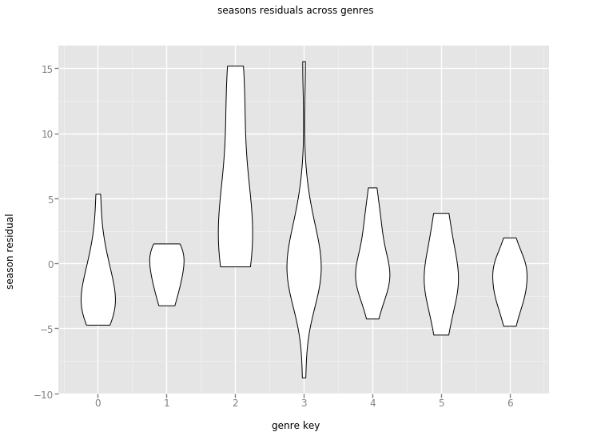

```python
ggplot(aes(x='genre_id', y='seasons_residuals'), data=df1) +\
    geom_violin() +\
    labs(title="seasons residuals across genres",
         x = "genre key",
         y = "season residual")
```

Animation shows perform much better than expected and last a long time, while comedy has a lot of variance in its residuals and Drama & Drama/Crime do not produce as many seasons as the audience wants (i.e. they want more!).

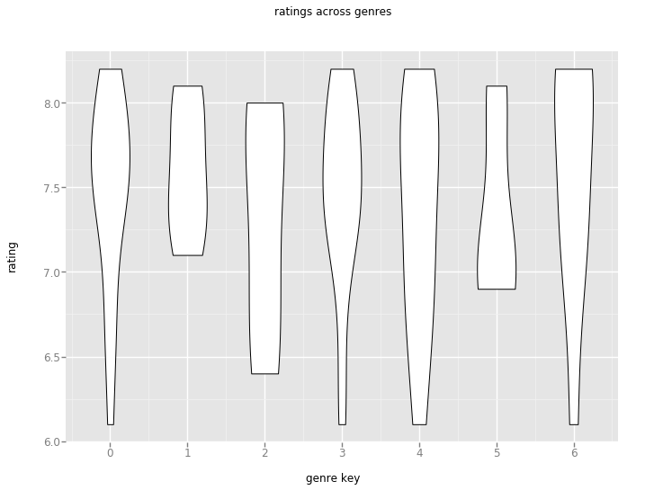

```python
ggplot(aes(x='genre_id', y='rating'), data=df1) +\
    geom_violin() +\
    labs(title="ratings across genres",
         x = "genre key",
         y = "rating")
```

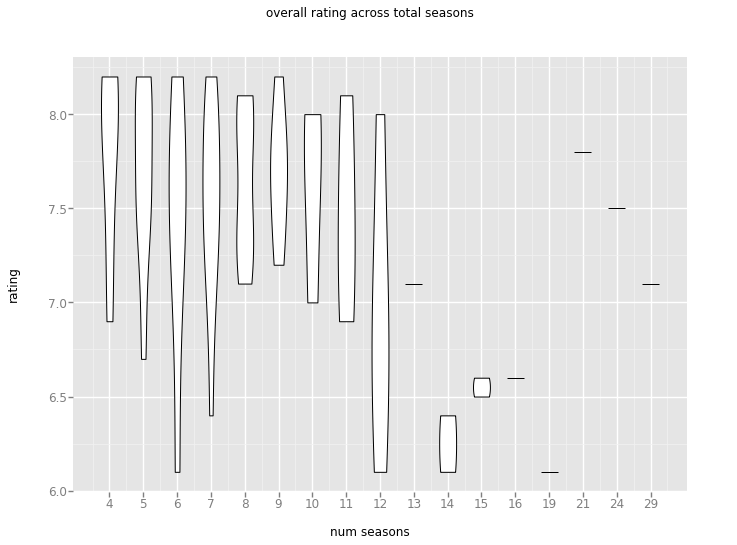

```python
ggplot(aes(x='seasons', y='rating'), data=df1) +\
    geom_violin() +\
    labs(title="overall rating across total seasons",
         x = "num seasons",
         y = "rating")
```

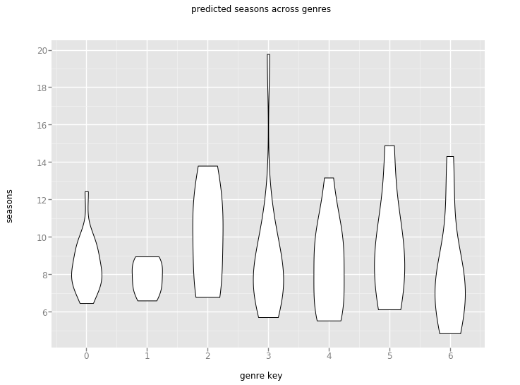

```python
ggplot(aes(x='genre_id', y='predicted_seasons'), data=df1) +\
    geom_violin() +\
    labs(title="predicted seasons across genres",
         x = "genre key",
         y = "seasons")
```

Comedies will either live to see a long life of their show, or go rather quickly. Comedy/Dramas seem to be a good investment as a hybrid show for networks, if they will make it to season 4, they'll probably produce 7-9 seasons.

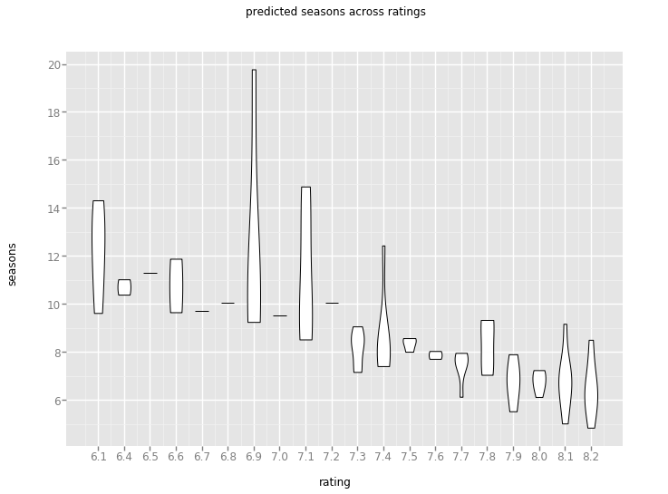

```python
ggplot(aes(x='rating', y='predicted_seasons'), data=df1) +\
    geom_violin() +\
    labs(title="predicted seasons across ratings",
         x = "rating",
         y = "seasons")
```

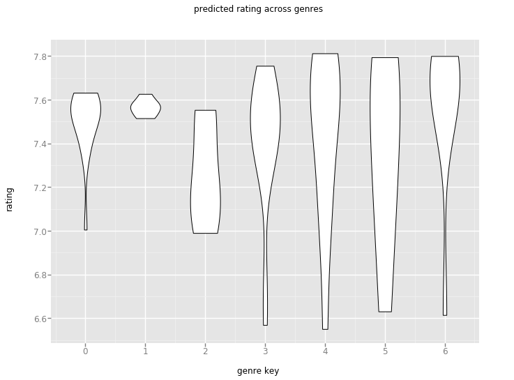

```python
ggplot(aes(x='genre_id', y='predicted_rating'), data=df1) +\
    geom_violin() +\
    labs(title="predicted rating across genres",
         x = "genre key",
         y = "rating")
```

Again, Comedy/Drama shows seem to be a good investment in quality.

Let's see how well our prediction models stack up against real life data and look and average rating across seasons.

```python
simpsons = df1[df1["tv_id"] == 456]
```

```python
simpsons
```

[output not shown]

```python
for x in range(1,30):
    season = tmdb.TV_Seasons(456, x)
    time.sleep(.251)
    info = season.info()

    try:
        curr = 0
        episodes = info.get("episodes")
        num = 0
        for ep in episodes:
            if ep.get("vote_count") > 0:
                curr += ep.get("vote_average")
                num += 1
        avg = curr / num
        key = "season" + str(x)
        simpsons[key] = avg
    except:
        pass
```

```python
simpsons
```

[output not shown]

1 rows × 40 columns

```python
x = []
y = []
for i in range(1,30):
    x.append(i)
    key = "season" + str(i)
    y.append(simpsons[key][0])
```

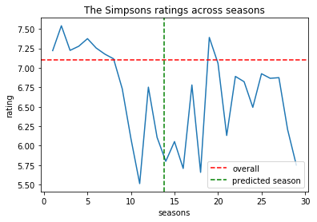

```python
plt.plot(x,y)
#rating = np.array( [simpsons["rating"] for i in range(len(x))] )
overall = plt.axhline(y=simpsons["rating"][0], color='r', linestyle='--', label='overall')
vert = plt.axvline(x=simpsons["predicted_seasons"][0], color='g', linestyle='--', label ='predicted season')
plt.legend(handles=[overall,vert], loc=4)
plt.xlabel("seasons")
plt.ylabel("rating")
plt.title("The Simpsons ratings across seasons")
plt.show()
```

Season 13/14 of the simpsons certainly was a relative low for the show, maybe it stayed past it's welcome

# Part 2

## Does the age of a cast influence reviews?

This section of the tutorial tests if and how the age of a cast influences reviews of movies. Like the previous section, the data is gathered from tmdb using their api and one of tmdb's api wrappers called tmdb simple. We hypothesize that older casts will tend to have higher reviews, since more experience may translate to better performances. We will test this hypothesis with the following steps:

1. Gathering data on movies with more than 200 votes
2. Cleaning and organizing the data in a pandas table
3. Plotting and analyzing lines of best fit

We believe this hypothesis is correct given how older actors often play younger parts. One interesting case was 41 year old Matt Damon playing a 17 year old. This phenomenon would suggest that older actors are better for the job than someone of an appropriate age, and that older actors are more talented. We assume that greater cast talent will translate into better reviews. Here's a comical list of older actors playing younger roles available on IMDb: http://www.imdb.com/list/ls079042158/.

## Data Gathering

#### Challenges

The data gathering process for movies on tmdb presented two main challenges: the unknown id's of movies and the rate limited api. The movie endpoint on tmdb requires a movieId parameter, but tmdb does not have any published list of id's. This means that we needed to iterate through every possible movie id until we reached the most recently added movie.

The movie id's range from 0 to around 500,000. Unfortunately, there are many indicies that do not correspond to any movie, so there are tens of thousands of invalid movie id's. This made it necessary to use try statements when accessing the return value for all the api calls. Given that we needed to iterate through 500,000, the 240/min api rate limit caused the gathering process to take around 48 hours.

Getting the ages of the actors required using tmdb's person endpoint, with the personId's gathered from the movie's cast list.

#### Approach

For the actual movie data we recorded, we only wanted data about movies with more than 200 votes. Otherwise, the ratings may not be so reliable. We also wanted to considered that there may be differences when dealing with the average age of the top 10, 6, 3 and lead role, so we calculated these data points in the tsv file. Overall, the tsv contains the following data points: title of movie, rating of movie (scale 1 to 10), release data, and the average age of the top 10, 6, 3, and 1 actors. The "top" actors are defined by the order that they appear in the cast list for each movie.

Note that we use -1 for the average age when the group is not complete (if there are 5 actors listed, age_6 will be -1 but age_3 will be recorded). Also, when referring to rating, we mean the 1-10 review scale, not G,R,etc.

The following functions were used to collect the data described above, which would be appended to the tsv.

```python
# This code was only run once to initialize the tsv

#with open("output.tsv", "w") as f:
#    print ("\t%s\t%s\t%s\t%s\t%s\t%s\t%s" % ("movie", "rating", "release", "age_10", "age_6", "age_3", "age_1"), file=f)
```

```python
# write a line to the tsv
def saveLine(index, movie, rating, release, age_10, age_6, age_3, age_1):
    with open("output.tsv", "a") as f:
        print ("%d\t%s\t%s\t%s\t%s\t%s\t%s\t%s" % (index, movie, rating, release, age_10, age_6, age_3, age_1), file=f)
```

```python
def getSingleAge(actID,release):
    person = tmdb.People(actID)
    try:
        bd = person.info().get('birthday')
        bd = parser.parse(bd)
        rl = parser.parse(release)
        delta = (rl - bd).days/365
        return round(delta,1)
    except:
        return -1

def getAges(actors,release,movieIndex,title,rating):
    age_10 = -1
    age_6 = -1
    age_3 = -1
    age_1 = -1
    ages = []

    q = len(actors)
    for x in range(q):
        time.sleep(.25)

        try:
            c = getSingleAge(actors[x].get('id'),release)
            if(c > 1):
                ages.append(c)
        except:
            ages = ages
    if(len(ages) > 9):
        age_10 = sum(ages)/10
    if(len(ages) > 5):
        age_6 = sum(ages[:6])/6
    if(len(ages) > 2):
        age_3 = sum(ages[:3])/3
    if(len(ages) > 0):
        age_1 = ages[0]
    saveLine(movieIndex,title,rating, release, age_10, age_6, age_3, age_1)


movieIndex = 500000

while(movieIndex < 500000):
    movie = tmdb.Movies(movieIndex)
    time.sleep(.25)
    actors = []
    try:
        info = movie.info()
        title = info.get('title')
        votes = info.get('vote_count')
        print(votes)
        if((int(votes) > 200) and hasattr(movie,'credits')):
            print('working')
            release = info.get('release_date')
            actors = movie.credits().get('cast')
            rating = info.get('vote_average')
            if(len(actors) > 9):
                actors = actors[:10]
            elif(len(actors) > 5):
                actors = actors[:6]
            elif(len(actors) > 2):
                actors = actors[:3]
            elif(len(actors) > 0):
                actors = actors[:1]

    except:
        print("Not valid")

    if(len(actors) > 0):
        getAges(actors,release,movieIndex,title,rating)

    print(movieIndex)
    movieIndex += 1
```

### Dataframe

Here's a sample of the 4200 rows of data that was collected. We use drop duplicates since there were a few duplicates from human error (not using the right index between gathering sessions).

```python
# load dataframe from tsv
ageData = pd.DataFrame.from_csv("output.tsv", sep='\t').drop_duplicates()
ageData.head()
```

|  | movie | rating | release | age_10 | age_6 | age_3 | age_1 |
| --- | --- | --- | --- | --- | --- | --- | --- |
| 5 | Four Rooms | 6.5 | 1995-12-09 | 32.81 | 35.183333 | 34.000000 | 34.6 |
| 11 | Star Wars | 8.1 | 1977-05-25 | 40.38 | 39.950000 | 27.066667 | 25.7 |
| 12 | Finding Nemo | 7.6 | 2003-05-30 | 44.63 | 40.850000 | 36.800000 | 55.9 |
| 13 | Forrest Gump | 8.3 | 1994-07-06 | -1.00 | 33.450000 | 35.200000 | 38.0 |
| 14 | American Beauty | 7.9 | 1999-09-15 | 35.55 | 31.466667 | 33.000000 | 40.2 |

## Age vs Reviews

Now let's have a quick look at the age-review relationships with some scatterplots with best fit lines. A 3 degree polynomial should be able to show us any important changes without too much overfitting.

#### Lead Role (age_1)

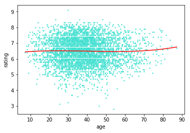

```python
temp = ageData.query('age_1 > 0')
plt.ylabel('rating')
plt.xlabel('age')
plt.plot(np.unique(temp.age_1), np.poly1d(np.polyfit(temp.age_1, temp.rating, 3))(np.unique(temp.age_1)), c="red")
plt.scatter(temp.age_1, temp.rating, s=2, c="turquoise")
plt.show()
```

#### Top 3 Actors (age_3)

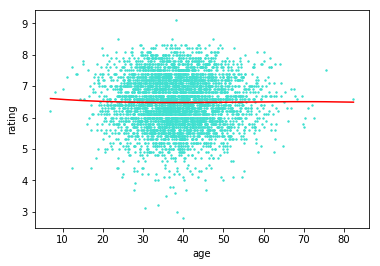

```python
temp = ageData.query('age_3 > 0')
plt.ylabel('rating')
plt.xlabel('age')
plt.plot(np.unique(temp.age_3), np.poly1d(np.polyfit(temp.age_3, temp.rating, 3))(np.unique(temp.age_3)), c="red")
plt.scatter(temp.age_3, temp.rating, s=2, c="turquoise")
plt.show()
```

#### Top 6 Actors (age_6)

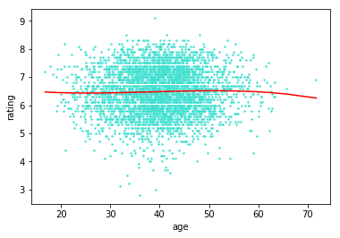

```python
temp = ageData.query('age_6 > 0')
plt.ylabel('rating')
plt.xlabel('age')
plt.plot(np.unique(temp.age_6), np.poly1d(np.polyfit(temp.age_6, temp.rating, 3))(np.unique(temp.age_6)), c="red")
plt.scatter(temp.age_6, temp.rating, s=2, c="turquoise")
plt.show()
```

#### Top 10 Actors (age_10)

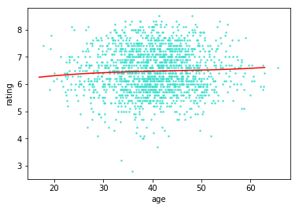

```python
temp = ageData.query('age_10 > 0')
plt.ylabel('rating')
plt.xlabel('age')
plt.plot(np.unique(temp.age_10), np.poly1d(np.polyfit(temp.age_10, temp.rating, 3))(np.unique(temp.age_10)), c="red")
plt.scatter(temp.age_6, temp.rating, s=2, c="turquoise")
plt.show()
```

### Going by the looks

By the pure look of the scatter plots and the trendline, there's no clear correlation. The data points look fairly evenly distributed around an average cast age of 40 and rating of 6.5.

### Going by the numbers

Let's see if there is any slope at all in the one-degree polynomial lines.

```python
print("Lead slope:")
print(np.poly1d(np.polyfit(temp.age_1, temp.rating, 1))[1])
print("Top 3 slope:")
print(np.poly1d(np.polyfit(temp.age_3, temp.rating, 1))[1])
print("Top 6 slope:")
print(np.poly1d(np.polyfit(temp.age_6, temp.rating, 1))[1])
print("Top 10 slope:")
print(np.poly1d(np.polyfit(temp.age_10, temp.rating, 1))[1])
```

```
Lead slope:
-0.00181079482964
Top 3 slope:
-0.00139562318732
Top 6 slope:
0.00318308057983
Top 10 slope:
0.00495935772605
```

## How did our hypothesis do?

After this brief analysis, it seems that there's no clear trend that merits more investigation. Our hypothesis that older actors make better movies is wrong. In fact, the age of cast members does not appear to have any influence on the quality of a movie. However, one interesting takeaway is that the scatterplots have fairly smooth distributions around the mean age and rating. While we can't prove our hypothesis, we can still use this data to deliver some fun facts...

# Part 2.5

Since we don't have much to say about the non-existent relationship between cast age and rating, we decided to test a quick hypothesis with this age data: Movies that are released in the summer have worse reviews than other months. We will test this with the same approach as the previous hypothesis with scatterplots and trendlines. Since there are only twelve points of data, we can get away with plotting the average with an overfitted trendline.

We think this is worth testing due to the recent press about bad summer movies in 2017. http://www.latimes.com/business/hollywood/la-fi-ct-movie-projector-summer-meltdown-20170830-story.html

#### Movie Rating vs Time

Here's a function to pull the mott of the YYYY-MM-DD release date.

```python
def reapYears(dateFrame):
    toReturn = []
    for x in dateFrame:
        year = int(x.split('-')[1])
        toReturn.append(year)
    return toReturn

q = ageData.copy(deep = True)
q['release'] = reapYears(q['release'])
q.head()
```

|  | movie | rating | release | age_10 | age_6 | age_3 | age_1 |
| --- | --- | --- | --- | --- | --- | --- | --- |
| 5 | Four Rooms | 6.5 | 12 | 32.81 | 35.183333 | 34.000000 | 34.6 |
| 11 | Star Wars | 8.1 | 5 | 40.38 | 39.950000 | 27.066667 | 25.7 |
| 12 | Finding Nemo | 7.6 | 5 | 44.63 | 40.850000 | 36.800000 | 55.9 |
| 13 | Forrest Gump | 8.3 | 7 | -1.00 | 33.450000 | 35.200000 | 38.0 |
| 14 | American Beauty | 7.9 | 9 | 35.55 | 31.466667 | 33.000000 | 40.2 |

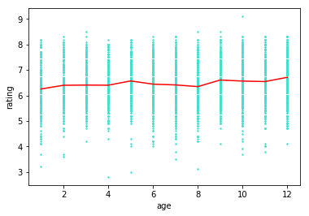

```python
q = q.query('age_1 > 0 ')
plt.ylabel('rating')
plt.xlabel('age')
plt.plot(np.unique(q.release), np.poly1d(np.polyfit(q.release, q.rating, 50))(np.unique(q.release)), c="red")
plt.scatter(q.release, q.rating, s=2, c="turquoise")
plt.show()
```

## Conclusion

This time we can observe a small movement downward in ratings over June through August, but this level of rating is roughly the same as Juanuary through April. We can't completely reject our hypothesis from this graph, but we also can't confirm it. Given that the we see no clear trend that's worth investigating further.

For both hypotheses in part 2, we did not necessarily expect to find a significant relationships. However, we were interested to test them and satisfied with the extent of our investigation given the underwhelming trends.

## Just for fun

These frames are not testing any hypothesis, but will deliver a few fun facts if you're interested movie data.

#### A horribly overfitted graph of lead age vs rating (30 degree polynomial)

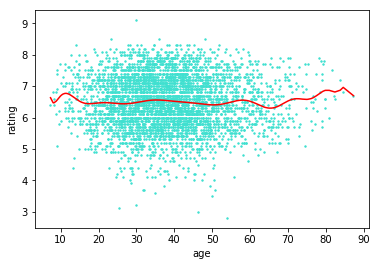

```python
temp = ageData.query('age_1 > 0')
plt.ylabel('rating')
plt.xlabel('age')
plt.plot(np.unique(temp.age_1), np.poly1d(np.polyfit(temp.age_1, temp.rating, 30))(np.unique(temp.age_1)), c="red")
plt.scatter(temp.age_1, temp.rating, s=2, c="turquoise")
plt.show()
```

#### Average ages of top cast members

```python
temp = ageData.query('age_1 > 0')
age_1_average = temp.mean()[5]
temp = ageData.query('age_3 > 0')
age_3_average = temp.mean()[4]
temp = ageData.query('age_6 > 0')
age_6_average = temp.mean()[3]
temp = ageData.query('age_10 > 0')
age_10_average = temp.mean()[2]

print("Lead average age:")
print(age_1_average)
print("Top 3 average age:")
print(age_3_average)
print("Top 6 average age:")
print(age_6_average)
print("Top 10 average age:")
print(age_10_average)
```

```
Lead average age:
38.315582559
Top 3 average age:
38.549684466
Top 6 average age:
40.0476247346
Top 10 average age:
40.8648532055
```

#### Average movie rating (for movies over 200 votes)

```python
ageData.mean()[0]
```

```
6.4928978622327822
```

#### Youngest Lead

```python
temp = ageData.query('age_1 > 0')
temp.min()[6]
```

```
7.3
```

```python
temp = temp.query('age_1 == 7.3')
temp
```

|  | movie | rating | release | age_10 | age_6 | age_3 | age_1 |
| --- | --- | --- | --- | --- | --- | --- | --- |
| 10510 | Miracle on 34th Street | 6.4 | 1994 | -1.0 | 39.633333 | 37.533333 | 7.3 |

#### Oldest Lead

```python
temp = ageData.query('age_1 > 0')
temp.max()[6]
```

```
87.3
```

```python
temp = temp.query('age_1 == 87.3')
temp
```

|  | movie | rating | release | age_10 | age_6 | age_3 | age_1 |
| --- | --- | --- | --- | --- | --- | --- | --- |
| 170522 | Asterix: The Mansions of the Gods | 6.7 | 2014 | -1.0 | 57.25 | 62.966667 | 87.3 |